# Last time...

- Simple linear regression
- Linear algebra breviary
  - Pre-multiplication (left-side) and Pos-multiplication (right-side)
  - **Left-side products** (*pre-multiplications*) affect the **row space** in $\mathbf{A}$
  - **Right-side products** (*pos-multiplications*) affect the **column space** in $\mathbf{A}$
  - Elementary matrix operations (Type I, II, III)
  - **Elementary matrix** is created by performing an **elementary operation** to an **identity matrix**.

# Linear regression - 1st Example: $\mathcal{D}=\{p_1, p_2\}$

In our linear regression example

$$ \begin{bmatrix} 1 & 1 \\ 1 & 3 \\ \end{bmatrix} \cdot \begin{bmatrix} \beta_{0}\\ \beta_{1} \end{bmatrix} = \begin{bmatrix} 1\\ 2 \end{bmatrix} $$

we used **row reduction** to solve the matrix equation

$$ \mathbf{A} \cdot \boldsymbol{\beta} = \mathbf{y} $$

We can summarize the row reduction as a sequence of **elementary matrix operations**

$$ \begin{bmatrix} 1 & 0\\ 0 & 1\\ \end{bmatrix} = \mathbf{E}_3 \cdot \mathbf{E}_2 \cdot \mathbf{E}_3 \cdot \begin{bmatrix} 1 & 1\\ 1 & 3\\ \end{bmatrix} $$

$$ \begin{bmatrix} 1 & 0\\ 0 & 1\\ \end{bmatrix} = \mathbf{E} \cdot \begin{bmatrix} 1 & 1\\ 1 & 3\\ \end{bmatrix} $$

$$ \mathbf{I} = \mathbf{E} \cdot \mathbf{A} $$

$$ \mathbf{E} = \mathbf{A}^{-1} $$

or equivalently,

$$ \begin{bmatrix} 1 & 0\\ 0 & 1\\ \end{bmatrix} = \begin{bmatrix} \frac{3}{2} & -\frac{1}{2} \\ -\frac{1}{2} & \frac{1}{2}\\ \end{bmatrix} \cdot \begin{bmatrix} 1 & 1\\ 1 & 3\\ \end{bmatrix} $$

therefore, by finding the **elementary matrices**, which drives $\mathbf{A}$ to $\mathbf{A}$, the identity matrix, we are actually finding the **inverse** of $\mathbf{A}$, denoted $\mathbf{A}^{-1}$.

> **How do we determine whether a matrix has an inverse?**
> - The invertible matrix theorem

Once we have $\mathbf{A}^{-1}$, we can write the following **pre-multiplication**

$$ \begin{align*} \mathbf{A}^{-1} \cdot \mathbf{A} \cdot \boldsymbol{\beta} &= \mathbf{A}^{-1} \cdot \mathbf{y} \\ \mathbf{I} \cdot \boldsymbol{\beta} &= \mathbf{A}^{-1} \cdot \mathbf{y} \\ \boldsymbol{\beta} &= \mathbf{A}^{-1} \cdot \mathbf{y} \end{align*} $$

which is the **exact solution** for our system of equations.

Notice that in our system

$$ \begin{bmatrix} 1 & 1 \\ 1 & 3 \\ \end{bmatrix} \cdot \begin{bmatrix} \beta_{0}\\ \beta_{1} \end{bmatrix} = \begin{bmatrix} 1\\ 2 \end{bmatrix} $$

we are looking for

$$ \beta_{0} \begin{bmatrix} 1 \\ 1 \end{bmatrix} + \beta_{1} \begin{bmatrix} 1 \\ 3 \end{bmatrix} = \begin{bmatrix} 1\\ 2 \end{bmatrix} $$

and we found the solution $ \boldsymbol{\beta} = \begin{bmatrix} \beta_{0}\\ \beta_{1} \end{bmatrix} = \begin{bmatrix} \frac{1}{2}\\ \frac{1}{2} \end{bmatrix} $

so, what we actually found was

$$ 0.5 \begin{bmatrix} 1 \\ 1 \end{bmatrix} + 0.5 \begin{bmatrix} 1 \\ 3 \end{bmatrix} = \begin{bmatrix} 1\\ 2 \end{bmatrix} $$

[figure not shown]

In summary...

the system $\mathbf{A} \cdot \boldsymbol{\beta} = \mathbf{y}$ has solution since $\mathbf{y} \in \mathcal{C}(\mathbf{A})$, i.e., it can be expressed as a **linear combination** of the vectors in $\mathcal{C}(\mathbf{A})$

$$ \begin{align*} \mathbf{y} &= \begin{bmatrix} \mathbf{A}_{*1} & \mathbf{A}_{*2} \\ \end{bmatrix} \cdot \begin{bmatrix} \beta_{0}\\ \beta_{1} \end{bmatrix} \\ &= \beta_{0}\mathbf{A}_{*1} + \beta_{1}\mathbf{A}_{*2} \end{align*} $$

> In general, $\mathbf{A}\cdot \mathbf{x}=\mathbf{b}$ has solution when $\mathbf{b} \in \; \mathcal{C}(\mathbf{A})$, i.e., when $\mathbf{b}$ is a **linear combination** of the columns in $\mathbf{A}$

# 2nd Example: $\mathcal{D}=\{p_1, p_2, p_3\}$

We moved to a something slightly more complicated, which was to **fit a line** through **three points**. Thus, our new system was given the followign dataset:

| point | x | y |
| --- | --- | --- |
| $p_1$ | 1 | 1 |
| $p_2$ | 3 | 2 |
| $p_3$ | 4 | 1.5 |

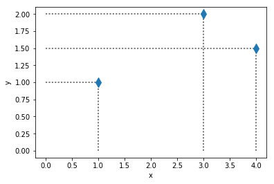

```python
import matplotlib.pyplot as plt
%matplotlib inline

# (1,1), (3,2), (4,1.5)
# horizontal lines
plt.plot([0, 1], [1,1], color='grey', linewidth=2,linestyle='dotted')
plt.plot([0, 3], [2,2], color='grey', linewidth=2,linestyle='dotted')
plt.plot([0, 4], [1.5,1.5], color='grey', linewidth=2,linestyle='dotted')
# vertical lines
plt.plot([1,1],[0,1], color='grey', linewidth=2,linestyle='dotted')
plt.plot([3,3],[0,2], color='grey', linewidth=2,linestyle='dotted')
plt.plot([4,4],[0,1.5], color='grey', linewidth=2,linestyle='dotted')

plt.plot([1,3,4],[1,2,1.5], 'd', markersize=10)
plt.xlabel('x')
plt.ylabel('y')
plt.show()
```

Due to there is no line that *exactly fit* these three points, we should be able to find, *at least*, the **closer line** to the points

- fortunately, the **matrix formulation** we have seen, has the virtue that it is **generalizable** when problems becomes more complicated.

As we know, in **linear regression**, our **hypothesis** is that the **functional relationship** *underlying* the data set can be **modeled** as a **line**, represented as:

$$ \begin{align*} y &= f(x) \\ &= \beta_0 x_0 + \beta_{1}x_{1} \quad \text{where $x_0=1$}\\ &= \sum_{i=0}^1 \beta_{i}x_{i} \\ \end{align*} $$

Thus, let's update our **system of equations** to accommodate the additional point $p_3$

| point | $x_0$ | $x_1$ | $y$ | M o d e l : $ y = \beta_{0} x_{0} + \beta_1 x_1 $ |
| --- | --- | --- | --- | --- |
| $p_1$ | 1 | 1 | 1 | $\small{1 = \beta_0 (1) + \beta_{1} (1)}$ |
| $p_2$ | 1 | 3 | 2 | $\small{2 = \beta_0 (1) + \beta_{1} (3)}$ |
| $p_3$ | 1 | 4 | 1.5 | $\small{ 1.5 = \beta_0 (1) + \beta_{1} (4)}$ |

> Now, in our updated system, we have **two unknowns** and **three equations** or **constraints**
> - this type of systems are commonly referred as **overdetermined system**
> - generally implies that there is no **exact solution**.

Again, the system can be written as the matrix equation $\mathbf{A} \cdot \boldsymbol{\beta} = \mathbf{y} $,

$$ \begin{bmatrix} 1 & 1 \\ 1 & 3 \\ 1 & 4 \\ \end{bmatrix} \cdot \begin{bmatrix} \beta_{0}\\ \beta_{1} \end{bmatrix} = \begin{bmatrix} 1\\ 2 \\ 1.5 \end{bmatrix} $$

```python
from numpy import matrix, dot
from numpy.linalg import  inv

A = matrix('1,1 ; 3,1 ; 4,1')
y = matrix('1 ; 2 ; 1.5')

beta= dot(inv(A), y)
```

```
---------------------------------------------------------------------------
LinAlgError                               Traceback (most recent call last)
<ipython-input-1-469fa74aa26e> in <module>()
      5 y = matrix('1 ; 2 ; 1.5')
      6
----> 7 beta= dot(inv(A), y)

/usr/lib/python3/dist-packages/numpy/linalg/linalg.py in inv(a)
    515     a, wrap = _makearray(a)
    516     _assertRankAtLeast2(a)
--> 517     _assertNdSquareness(a)
    518     t, result_t = _commonType(a)
    519

/usr/lib/python3/dist-packages/numpy/linalg/linalg.py in _assertNdSquareness(*arrays)
    210     for a in arrays:
    211         if max(a.shape[-2:]) != min(a.shape[-2:]):
--> 212             raise LinAlgError('Last 2 dimensions of the array must be square')
    213
    214 def _assertFinite(*arrays):

LinAlgError: Last 2 dimensions of the array must be square
```

> **NOTE**: What this **error** basically says is that the linear system cannot be solved explicitly.

# Least Squares Approximation

**Least Squares** method, allows to find an **approximate solution** that *automagically minimizes* the overall **approximation error**

- it is a standard approach in **regression analysis**
- it is useful when dealing with **overdetermined systems** (**constraints** >> **unknowns**)

*When a system of equations have no solution*?

$$ \begin{align*} \mathbf{y} &= \mathbf{A}\cdot \boldsymbol{\beta} \\ &= \begin{bmatrix} \mathbf{A}_{*1} & \mathbf{A}_{*2} & \ldots & \mathbf{A}_{*n} \end{bmatrix} \cdot \begin{bmatrix} \beta_1 \\ \beta_2 \\ \vdots \\ \beta_n \end{bmatrix}\\ &= \beta_1 \mathbf{A}_{*1} + \beta_2 \mathbf{A}_{*2} + \ldots + \beta_n \mathbf{A}_{*n} \end{align*} $$

Having **no solution** means that there is no **linear combination** for the columns of $\mathbf{A}_{m\times n}$, or more properly the **vectors** in $\mathcal{C}(\mathbf{A})$, which yields $\mathbf{y}$

- $\mathbf{y}$ is not in $\mathcal{C}(\mathbf{A})$
- there is no $\boldsymbol{\beta}$, or a set of $\beta_i$'s, that yield $\mathbf{y}$

[figure not shown]

Since there is no $\boldsymbol{\beta}$ that provides an **exact solution** for $\mathbf{y} = \mathbf{A}\cdot \boldsymbol{\beta}$, we can try to find a $\widehat{\boldsymbol{\beta}}$ such that $\mathbf{y} \approx \mathbf{A}\cdot \widehat{\boldsymbol{\beta}}$, i.e., is *as close as possible* to $\mathbf{y}$

- notice that $ \mathbf{A}\cdot \widehat{\boldsymbol{\beta}} \in \; \mathcal{C}(\mathbf{A})$

[figure not shown]

*How do we select* $\widehat{\boldsymbol{\beta}}$ ?

The criterion or strategy to choose $\widehat{\boldsymbol{\beta}}$, is to *minimize* the **distance/norm** between the vectors $\mathbf{y}$ and $\mathbf{A}\cdot \widehat{\boldsymbol{\beta}}$

- **Euclidean distance** is the **ordinary** straight-line distance between two points
- a generalized term for the Euclidean distance is the $\mathbf{L^2}$ **norm/distance**
- $\mathbf{L^p}$ spaces are function spaces defined using a natural generalization of the $p$-norm for finite-dimensional **vector spaces**, sometimes called **Lebesgue spaces**.

[figure not shown]

# Vector Norm

Given an $n$-dimensional vector

$$ \mathbf{x} = \begin{bmatrix} x_1 \\ x_2 \\ \vdots \\ x_n \end{bmatrix}$$

the **vector norm** or $\lVert x\rVert_{p}$ for $p=1, 2, \ldots$ is defined as

$$ \lVert x\rVert_{p} = \left( \sum_{i}|x_{i}|^p \right)^{1/p} $$

The most commonly encountered vector norm (often called **the norm of a vector**, or **the magnitude** of a vector) is the $L^2$-norm, given by

$$ \begin{align*} \lVert x\rVert_2 & = \sqrt{x_1^2+x_2^2+...+x_n^2} \\ &= \left\| x \right\| \\ &= | \; x\; | \\ \end{align*} $$

This and other types of **vector norms** are summarized in the following table, together with the value of the norm for the example vector $v=(1,2,3)$

| name | symbol | value | approx |
| --- | --- | --- | --- |
| $L^1$-norm | $\lVert x \rVert_1$ | $6$ | 6.000 |
| $L^2$-norm | $\lVert x \rVert_2$ | $14^{1/2} $ | 3.742 |
| $L^3$-norm | $\lVert x \rVert_3$ | $6^{2/3}$ | 3.302 |
| $L^4$-norm | $\lVert x \rVert_4$ | $2^{1/4} 7^{1/2}$ | 3.146 |
| $L^\infty$-norm | $\lVert x \rVert_\infty$ | $3$ | 3.000 |

Now, once we have defined our measure of **distance** as the **vector norm**, let $\mathbf{v} = \mathbf{A}\cdot \widehat{\boldsymbol{\beta}}$, so we can rewrite the **distance** between $\mathbf{y}$ and $\mathbf{A}\cdot \widehat{\boldsymbol{\beta}}$

[figure not shown]

We want to *minimize* or to make the **distance/norm** between $\mathbf{y}$ and $\mathbf{v}$ the **least value** that it can be

$$ \begin{align*} \left\| \mathbf{y} - \mathbf{A}\cdot \widehat{\boldsymbol{\beta}}\right\| &= \left\|\mathbf{y}-\mathbf{v}\right\| \\ &= \left\| \begin{pmatrix} y_1 - v_1 \\ \vdots \\ y_m - v_m \end{pmatrix}\right\| \\ & = \sqrt{(y_1 - v_1)^2 + \ldots + (y_m - v_m)^2} \\ \end{align*} $$

where $v_i$ is the $i$th row of $\mathbf{v} = \mathbf{A}\cdot \widehat{\boldsymbol{\beta}}$.

Let's write the **squared norm** of these two vectors

$$ \begin{align*} \mathcal{S} &= \left\|\mathbf{y}-\mathbf{v}\right\|^2 \\ &= (y_1 - v_1)^2 + \ldots + (y_m - v_m)^2 \\ &= \sum_{1}^{m} (y_i - v_i)^2 \end{align*} $$

so, we want to make this value the **least value** that it can be possible, in other words, we want to solve the **optimization problem**

$$ \begin{equation*} \begin{aligned} & \text{minimize} & & \mathcal{S(\widehat{\boldsymbol{\beta}})} \\ & \text{subject to} & & y_i = f_i(\mathbf{x}) , \; i = 1, \ldots, m. \end{aligned} \end{equation*} $$

> this is why $\widehat{\boldsymbol{\beta}}$ is called the **least square estimation**, or **least square solution**, or **least square approximation** for the equation $\mathbf{A}\cdot \boldsymbol{\beta} = \mathbf{y}$
> - similar to **utility maximization**/ **cost minimization**

**What is the closest vector** and **how to find it**?

From the **approximation theory**, we know that the *closest vector* $\mathbf{v}$ in any subspace to a vector $\mathbf{y}$ that is not in the subspace is goin to be the **projection** of $\mathbf{y}$ onto the subspace

$$ \mathbf{proj}_{\mathbf{v}}\mathbf{w} = \frac{\mathbf{w} \cdot \mathbf{v}} {\left\| \mathbf{v} \right\| ^2} \mathbf{v} $$

therefore , we are looking for

$$ \mathbf{v}= \mathbf{A}\cdot \widehat{\boldsymbol{\beta}} = \mathbf{proj}_{\mathcal{C}(\mathbf{A})}\mathbf{y} $$

[figure not shown]

now, if we substract $\mathbf{y}$ from the last expression

$$ \boldsymbol{\epsilon} = \mathbf{proj}_{\mathcal{C}(\mathbf{A})}\mathbf{y} - \mathbf{y} $$

[figure not shown]

it can be shown that $\boldsymbol{\epsilon} = \mathbf{A}\cdot \widehat{\boldsymbol{\beta}}- \mathbf{y}$ is an element of the **orthogonal complement** of the **column space** of $\mathbf{A}$

$$ \boldsymbol{\epsilon} \in \; \mathcal{C}(\mathbf{A})^{\perp} $$

but

$$ \mathcal{C}(\mathbf{A})^{\perp} = \mathcal{N}(\mathbf{A}^T) $$

then

$$ \boldsymbol{\epsilon} = \mathbf{A}\cdot \widehat{\boldsymbol{\beta}}- \mathbf{y} \in \; \mathcal{N}(\mathbf{A}^T) $$

[figure not shown]

therefore,

$$ \begin{align*} \mathbf{A}^{T}\boldsymbol{\epsilon} &= \mathbf{0} \\ \mathbf{A}^{T}(\mathbf{A}\;\widehat{\boldsymbol{\beta}}-\mathbf{y}) &= \mathbf{0} \\ \mathbf{A}^{T} \mathbf{A}\;\widehat{\boldsymbol{\beta}}-\mathbf{A}^{T}\mathbf{y} &= \mathbf{0} \\ \mathbf{A}^{T}\mathbf{A}\;\widehat{\boldsymbol{\beta}} &= \mathbf{A}^{T}\mathbf{y} \end{align*} $$

# Normal equations

- For an $m\times n$ system $\mathbf{A}\mathbf{x} = \mathbf{b}$, the associated system of **normal equations** is defined to be the $n\times n$ system

$$ \mathbf{A}^{T}\mathbf{A}\;\hat{\mathbf{x}} = \mathbf{A}^{T}\mathbf{b} $$

- When $\mathbf{A}\mathbf{x} = \mathbf{b}$ is consistent, its solution set agrees with that of $ \mathbf{A}^{T}\mathbf{A}\hat{\mathbf{x}} = \mathbf{A}^{T}\mathbf{b}$. Then, the normal equations provide **least squares solution** to $\mathbf{A}\mathbf{x} = \mathbf{b}$ when is **inconsistent**
- $ \mathbf{A}^{T}\mathbf{A}\hat{\mathbf{x}} = \mathbf{A}^{T}\mathbf{b}$ has a unique solution if and only if $rank (\mathbf{A}) = n$, in which case the unique solution is

$$ \mathbf{x} = (\mathbf{A}^{T}\mathbf{A})^{-1} \mathbf{A}^{T} \mathbf{b} $$

> The normal equation is that which minimizes the **sum of the square differences** between the left and right sides of the system $\mathbf{A}^{T}\mathbf{A}\hat{\mathbf{x}} = \mathbf{A}^{T}\mathbf{b}$

> It is called a **normal equation** because:
> - $\mathbf{A}\cdot \widehat{\boldsymbol{\beta}}- \mathbf{y}$ is normal to the **range** (column space) of $\mathbf{A}$
> - $\mathbf{A}^{T}\cdot \mathbf{A}$ is a normal matrix.

[figure not shown]

# Least squares in Python

### Example

```
[[ 3.5]
 [ 1.4]]
```

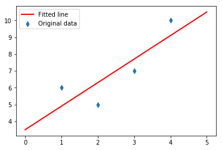

```python
import numpy as np
import matplotlib.pyplot as plt
%matplotlib inline

A = np.array([[1, 6],[2, 5],[3, 7],[4, 10]])
m = len(A)

X = np.array([np.ones(m), A[:, 0]]).T
y = np.array(A[:, 1]).reshape(-1, 1)

betaHat = np.linalg.solve(X.T.dot(X), X.T.dot(y))
print(betaHat)

plt.figure(1)
xx = np.linspace(0, 5, 2)
yy = np.array(betaHat[0] + betaHat[1] * xx)
plt.plot(xx, yy.T, color='r',lw = 2, label='Fitted line')
plt.scatter(A[:, 0], A[:, 1], marker='d' ,label='Original data')
plt.legend()
plt.show()
```

In Python, we can use **least-squares-fitting** (**`numpy.linalg.lstsq`**), to find the **exact solution**

```
[[ 0.5]] [[ 0.5]] [] 2
```

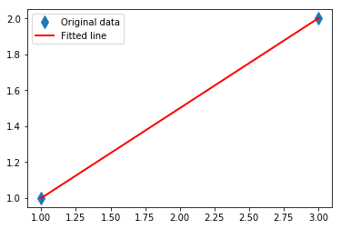

```python
from numpy import matrix
from numpy.linalg import lstsq
import matplotlib.pyplot as plt
%matplotlib inline


A = matrix('1,1 ; 3,1')
y = matrix('1 ; 2 ')

soln = lstsq(A, y)

beta1, beta0 = soln[0]  # Least-squares solution
e =  soln[1]    # Residuals - squared Euclidean 2-norm
rank = soln[2]  # Rank of matrix A

print(beta1, beta0, e, rank)

x = A[:,0]
plt.plot(x, y, 'd', label='Original data', markersize=10)
plt.plot(x, x*beta1 + beta0, 'r', label='Fitted line', lw = 2)
plt.legend()
plt.show()
```

In Python, we can use **least-squares-fitting** (**`numpy.linalg.lstsq`**), to find an **approximate solution**

```
[[ 0.21428571]] [[ 0.92857143]] [[ 0.28571429]] 2
```

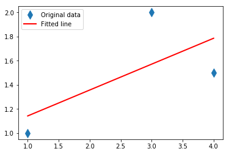

```python
from numpy import matrix
from numpy.linalg import lstsq
import matplotlib.pyplot as plt
%matplotlib inline


A = matrix('1,1 ; 3,1 ; 4,1')
y = matrix('1 ; 2 ; 1.5')

soln = lstsq(A, y)

m, c = soln[0]  # Least-squares solution
e =  soln[1]    # Sums of residuals
rank = soln[2]  # Rank of matrix A
print(m, c, e, rank)

x = A[:,0]
plt.plot(x, y, 'd', label='Original data', markersize=10)
plt.plot(x, x*m + c, 'r', label='Fitted line', lw = 2)
plt.legend()
plt.show()
```